# Graphs in Base R: Box Plots (aka Box-and-Whisker Plots) with Multiple Groups

⇦ Back

For this page we will use data from the finals of various Olympic events, available on Wikipedia.

This page functions as a follow-on from Boxplots with One Group of Data.

# 1 Too Simple

If we try to plot multiple datasets (eg the results from more than one Olympic Games) with two groups within each dataset (men and women), things start to become confusing:

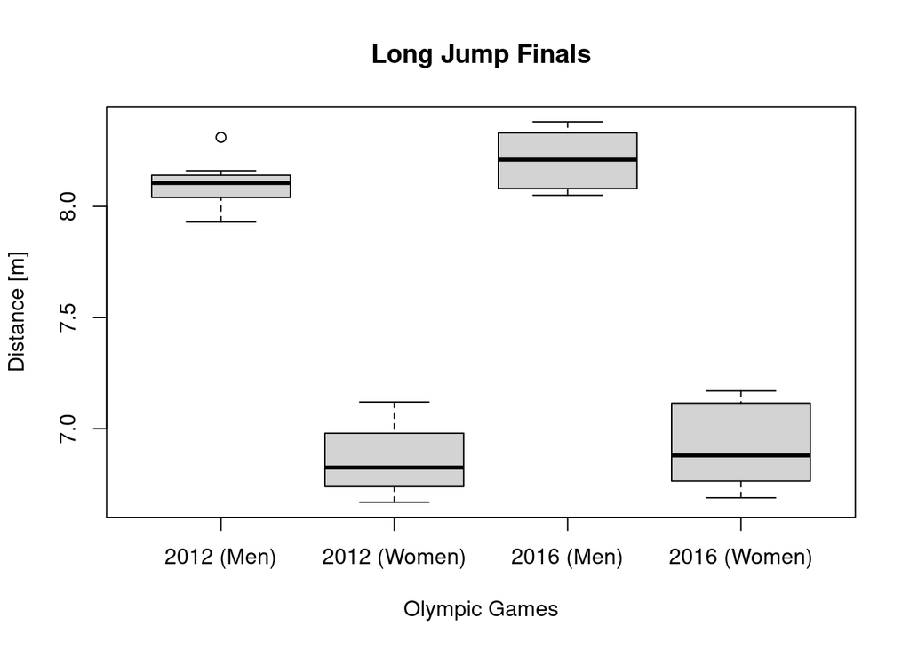

```r
long_jump <- data.frame(
    olympics = c(
        rep("London 2012 (Men)", 8), rep("Rio 2016 (Men)", 8),
        rep("London 2012 (Women)", 8), rep("Rio 2016 (Women)", 8)
    ),
    distance = c(
        8.31, 8.16, 8.12, 8.11, 8.10, 8.07, 8.01, 7.93,
        8.38, 8.37, 8.29, 8.25, 8.17, 8.10, 8.06, 8.05,
        7.12, 7.07, 6.89, 6.88, 6.77, 6.76, 6.72, 6.67,
        7.17, 7.15, 7.08, 6.95, 6.81, 6.79, 6.74, 6.69
    )
)

boxplot(
    distance ~ olympics, data = long_jump,
    main = "Long Jump Finals",
    xlab = "Olympic Games", ylab = "Distance [m]",
    names = c("2012 (Men)", "2012 (Women)", "2016 (Men)", "2016 (Women)")
)
```

In the above figure we just have four distinct box plots without the groups having been separated out.

# 2 A Better Approach

It’s a good idea to use the **ordering** of the box plots to show the different data sets. This will help to make things as clear as possible. This can be achieved by creating a separate column in the data frame for the ‘group’ or ‘category’ of the data - in this case men and women - and ‘multiplying’ by this column with the `*` symbol. For example, take a column called `men_women` and use `distance ~ olympics * men_women` as the input to the `boxplot()` function:

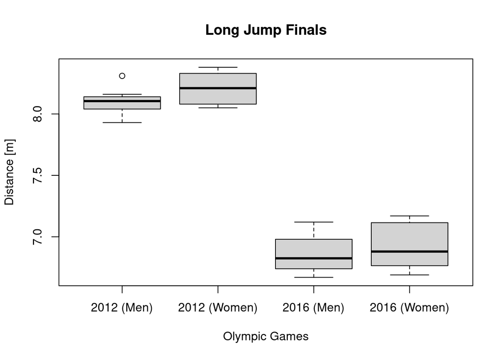

```r
long_jump <- data.frame(
    olympics = c(
        rep("London 2012", 8), rep("Rio 2016", 8),
        rep("London 2012", 8), rep("Rio 2016", 8)
    ),
    men_women = c(rep("Men", 16), rep("Women", 16)),
    distance = c(
        8.31, 8.16, 8.12, 8.11, 8.10, 8.07, 8.01, 7.93,
        8.38, 8.37, 8.29, 8.25, 8.17, 8.10, 8.06, 8.05,
        7.12, 7.07, 6.89, 6.88, 6.77, 6.76, 6.72, 6.67,
        7.17, 7.15, 7.08, 6.95, 6.81, 6.79, 6.74, 6.69
    )
)

boxplot(
    distance ~ olympics * men_women, data = long_jump,
    main = "Long Jump Finals",
    xlab = "Olympic Games", ylab = "Distance [m]",
    names = c("2012 (Men)", "2012 (Women)", "2016 (Men)", "2016 (Women)")
)
```

## 2.1 Re-label the x-Axis

The solution above still has four distinct boxplots, so edit the x-axis labels to clean things up:

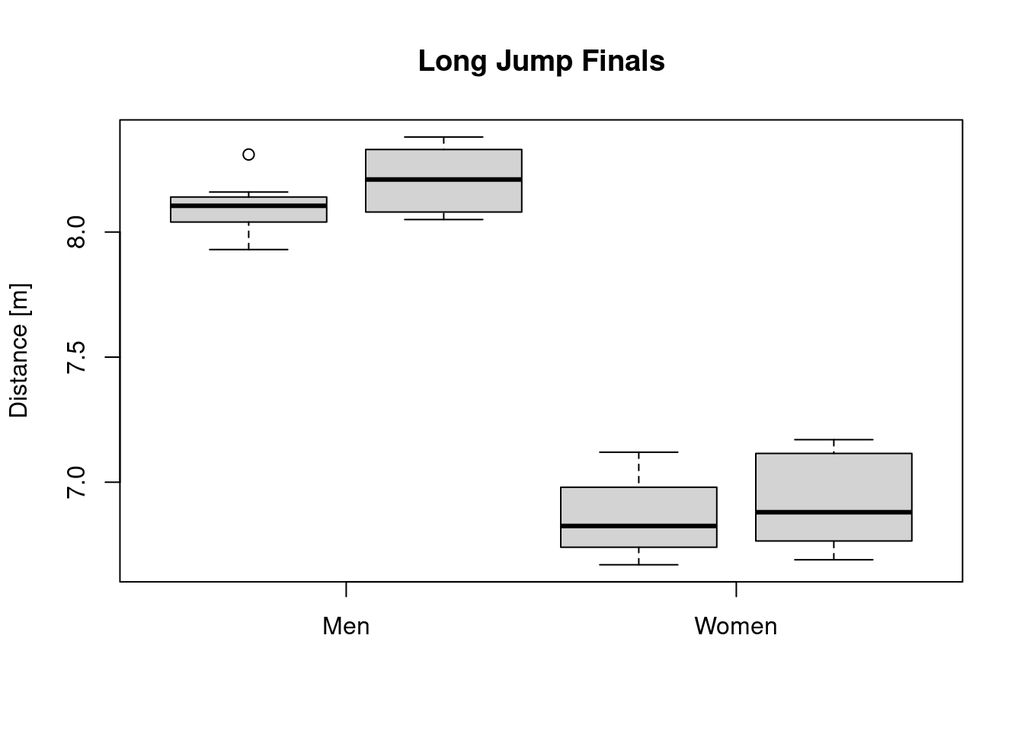

```r
boxplot(
    distance ~ olympics * men_women, data = long_jump, xaxt = "n",
    main = "Long Jump Finals", xlab = "", ylab = "Distance [m]"
)
axis(side = 1, at = c(1.5, 3.5), labels = c("Men", "Women"))
```

## 2.2 Colours and Legend

Now edit the colours and add a legend:

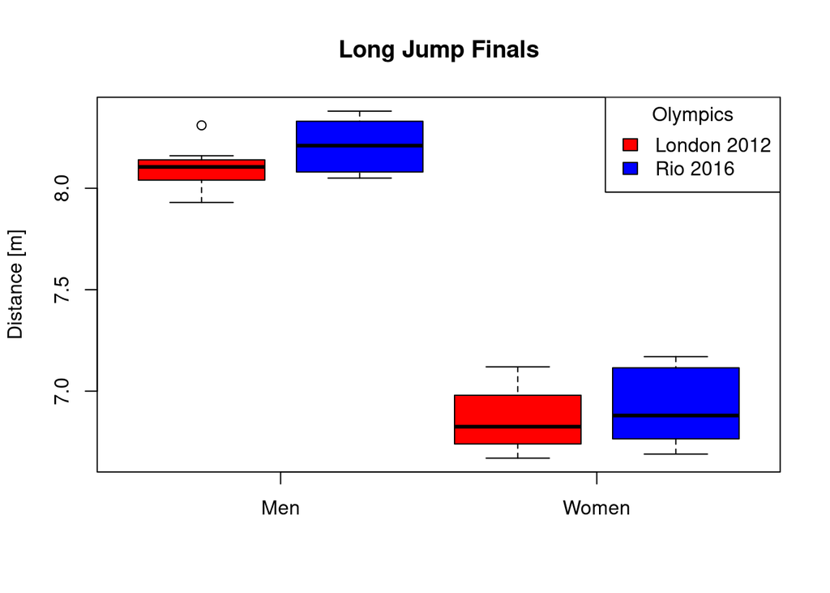

```r
boxplot(
    distance ~ olympics * men_women, data = long_jump, xaxt = "n",
    main = "Long Jump Finals", xlab = "", ylab = "Distance [m]",
    col = c("red", "blue")
)
axis(side = 1, at = c(1.5, 3.5), labels = c("Men", "Women"))
legend(
    "topright", title = "Olympics",
    legend = c("London 2012", "Rio 2016"), fill = c("red", "blue")
)
```

# 3 Scaling Up

If more data is added the graph can be updated with minimal changes to the code:

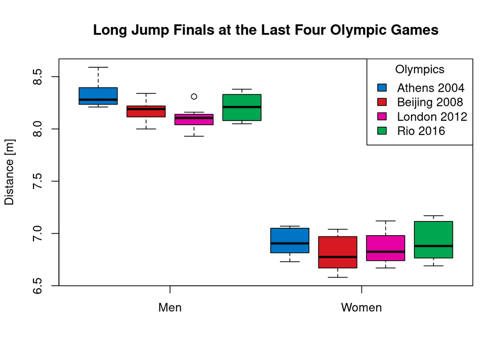

```r
long_jump <- data.frame(
    olympics = c(
        rep("Athens 2004", 8), rep("Beijing 2008", 8), rep("London 2012", 8), rep("Rio 2016", 8),
        rep("Athens 2004", 8), rep("Beijing 2008", 8), rep("London 2012", 8), rep("Rio 2016", 8)
    ),
    men_women = c(rep("Men", 32), rep("Women", 32)),
    distance = c(
        8.59, 8.47, 8.32, 8.31, 8.25, 8.24, 8.23, 8.21,
        8.34, 8.24, 8.20, 8.19, 8.19, 8.16, 8.07, 8.00,
        8.31, 8.16, 8.12, 8.11, 8.10, 8.07, 8.01, 7.93,
        8.38, 8.37, 8.29, 8.25, 8.17, 8.10, 8.06, 8.05,
        7.07, 7.05, 7.05, 6.96, 6.85, 6.83, 6.80, 6.73,
        7.04, 7.03, 6.91, 6.79, 6.76, 6.70, 6.64, 6.58,
        7.12, 7.07, 6.89, 6.88, 6.77, 6.76, 6.72, 6.67,
        7.17, 7.15, 7.08, 6.95, 6.81, 6.79, 6.74, 6.69
    )
)

boxplot(
    distance ~ olympics * men_women, data = long_jump,
    main = "Long Jump Finals at the Last Four Olympic Games",
    xlab = "", ylab = "Distance [m]", xaxt = "n",
    col = c("#0074c5", "#d71921", "#e400a3", "#00a650")
)
axis(side = 1, at = c(2.5, 6.5), labels = c("Men", "Women"))
legend(
    "topright", title = "Olympics",
    legend = c("Athens 2004", "Beijing 2008", "London 2012", "Rio 2016"),
    fill = c("#0074c5", "#d71921", "#e400a3", "#00a650")
)
```

# 4 Annotate the Summary Statistics

It can be very useful to include summary statistics right on the plot as opposed to hidden away in a paragraph of text.

## 4.1 Sample Sizes

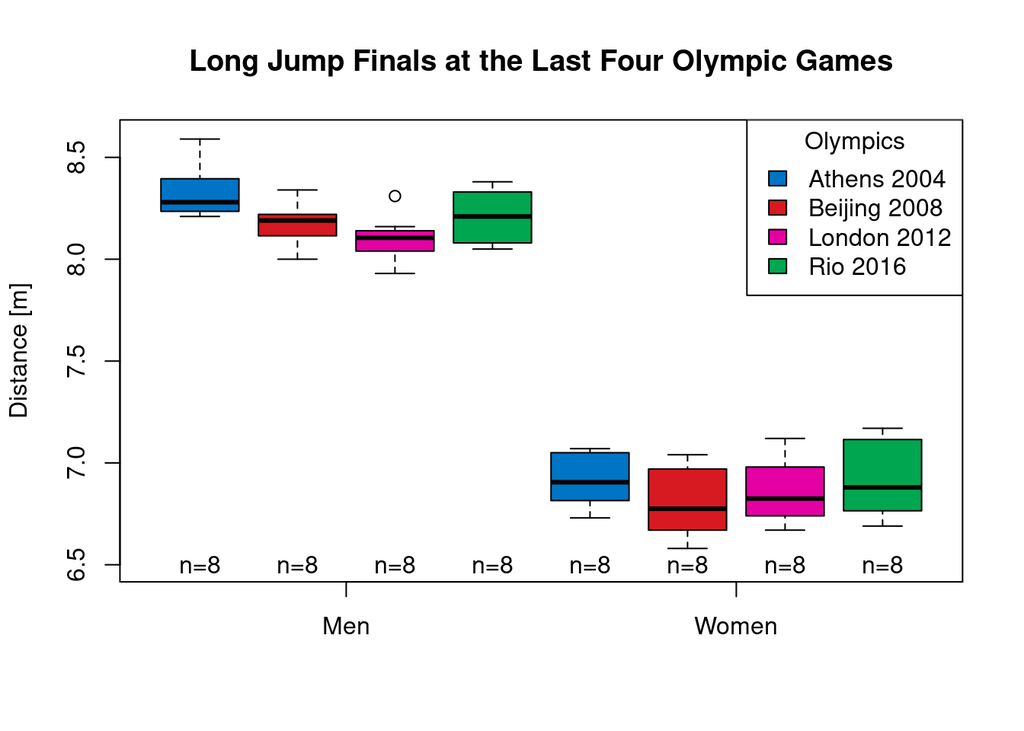

```r
boxplot(
    distance ~ olympics * men_women, data = long_jump,
    main = "Long Jump Finals at the Last Four Olympic Games",
    xlab = "", ylab = "Distance [m]", xaxt = "n",
    col = c("#0074c5", "#d71921", "#e400a3", "#00a650"),
    ylim = c(6.5, 8.6)
)
axis(side = 1, at = c(2.5, 6.5), labels = c("Men", "Women"))
legend(
    "topright", title = "Olympics",
    legend = c("Athens 2004", "Beijing 2008", "London 2012", "Rio 2016"),
    fill = c("#0074c5", "#d71921", "#e400a3", "#00a650")
)
sample_sizes <- aggregate(
    long_jump$distance, list(long_jump$olympics, long_jump$men_women), length
)
text(
    1:length(sample_sizes$x), 6.5,
    labels = paste0("n=", signif(sample_sizes$x, digits = 3))
)
```

## 4.2 Sample Means

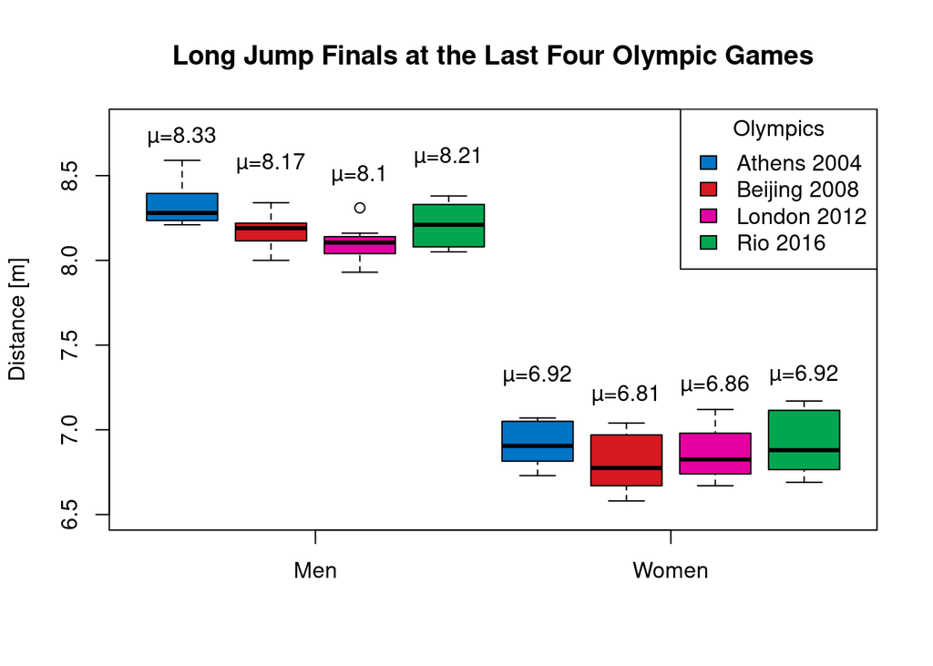

```r
boxplot(
    distance ~ olympics * men_women, data = long_jump,
    main = "Long Jump Finals at the Last Four Olympic Games",
    xlab = "", ylab = "Distance [m]", xaxt = "n",
    col = c("#0074c5", "#d71921", "#e400a3", "#00a650"),
    ylim = c(6.5, 8.8)
)
axis(side = 1, at = c(2.5, 6.5), labels = c("Men", "Women"))
legend(
    "topright", title = "Olympics",
    legend = c("Athens 2004", "Beijing 2008", "London 2012", "Rio 2016"),
    fill = c("#0074c5", "#d71921", "#e400a3", "#00a650")
)
means <- aggregate(
    long_jump$distance, list(long_jump$olympics, long_jump$men_women), mean
)
text(
    1:length(means$x), means$x + 0.4,
    labels = paste0("\U00B5=", signif(means$x, digits = 3))
)
```

# 5 Save Plot

Finally, save your plot to your computer as an image using one of the following (depending on what format you want the image to be in):

- `png("File Name.png")`
- `pdf("File Name.pdf")`

Whichever one you use, it must come *before* you start plotting the graph (ie before you call `boxplot()`).

⇦ Back